# **Customer Segmentation Analysis: for Personalized Marketing Strategies**

by Lau Wen Jun

1. Background
2. Problem Statement
3. Variables
4. Data Prerocessing
   - 4.1. Feature Scaling (Standardization)
   - 4.2. Transformed Data Output
   - 4.3. Dimensionality Reduction
5. K-Means Clustering
   - 5.1. Sturges' Rule
   - 5.2. Elbow Method
   - 5.3. Silhouette Score
   - 5.4. Silhouette Plots
   - 5.5. Optimal K
6. Cluster Analysis
   - 6.1. 3D Visualization of Customer Segmentation Using PCA
   - 6.2. Cluster Distribution
   - 6.3. Customer Behaviour Analysis
     - 6.3.1. Cluster 1: Young Digital-Savvy Spenders
     - 6.3.2. Cluster 2: Established Traditional Shoppers
     - 6.3.3. Cluster 3: Mid-Career Digital Enthusiasts
     - 6.3.4. Cluster 4: Value-Seeking Tech Adopters
7. Marketing Strategies & Recommendation
8. Discussion
9. Conclusion

## 1. Background

In today’s competitive market, understanding customer behavior is essential for businesses to optimize their marketing strategies, product offerings, and customer engagement efforts. With the rise of e-commerce and omnichannel retailing, consumers interact with brands across multiple touchpoints, leading to diverse purchasing behaviors and preferences. Identifying distinct customer segments allows businesses to tailor their approaches, ensuring personalized experiences that drive higher engagement, conversion rates, and long-term loyalty.

Customer segmentation is a powerful tool that enables companies to group customers based on demographics, shopping behaviors, and spending patterns. By leveraging machine learning techniques such as K-Means clustering, businesses can analyze vast amounts of data to uncover hidden patterns and gain actionable insights into consumer habits. This data-driven approach helps in designing effective promotions, pricing strategies, and personalized recommendations, ultimately leading to enhanced customer satisfaction and business growth.

## 2. Problem Statement

Despite the availability of vast consumer data, many businesses struggle to effectively segment their customers and implement targeted marketing strategies. Traditional segmentation methods often rely on basic demographics and fail to capture complex behavioral traits such as purchase frequency, spending habits, and product preferences. This limitation results in generic marketing campaigns that fail to resonate with specific customer groups, leading to missed opportunities for engagement and revenue growth.

To address this challenge, this portfolio applies K-Means clustering to categorize customers into distinct segments based on their shopping behavior, spending patterns, and preferred product categories. By analyzing these clusters, businesses can develop personalized marketing campaigns, loyalty programs, and promotional strategies that better align with customer needs. This segmentation approach aims to bridge the gap between data analytics and strategic decision-making, ensuring a more customer-centric business model that enhances both consumer experience and profitability.

## 3. Variables

This dataset contains **2000 synthetic customer records with 10 key attributes** that describe customer demographics, financial metrics, purchasing behavior, and product preferences. It is **not real-life data** but has been generated for **demonstration purposes** in **customer segmentation analysis**.

The dataset is designed to facilitate the study of **customer behavior patterns** and to help identify distinct groups of customers based on their spending habits, income levels, and shopping preferences.

1. **Customer Demographics**
- *Customer_ID (int)*: A unique identifier assigned to each customer.
- *Age (int)*: The age of the customer, ranging from 22 to 58 years with an average of 39.39 years.
- *Gender (object)*: The gender of the customer, categorized as Male or Female.
2. **Financial Attributes**
- *Annual_Income (int)*: The annual earnings of the customer in currency units, ranging from 49,180 to 116,601, with a mean income of 85,417.
- *Spending_Score (int)*: A metric measuring the customer's spending behavior, ranging from 10 to 99, with a median value of 60. Higher values indicate higher spending tendencies.
3. **Subscription & Engagement Behavior**
- *Subscription_Type (object)*: The type of subscription plan the customer has chosen, categorized as Basic, Standard, or Premium.
- *Purchase_Frequency (int)*: The number of purchases made within a specific time frame, ranging from 1 to 29 purchases, with a median value of 10.
- *Customer_Tenure (int)*: The number of years the customer has been active, ranging from 1 to 9 years, with an average tenure of 4.66 years.
4. **Purchasing Channels & Preferences**
- *Channel (object)*: The primary shopping medium used by the customer, categorized as Online, In-Store, or Mobile App.
- *Product_Category (object)*: The preferred product category of the customer, including Electronics, Clothing, Automotive, Beauty, Sports, Toys, Books, and Home & Kitchen.

```python
import pandas as pd
import numpy as np
import matplotlib.pyplot as plt
import seaborn as sns
from sklearn.preprocessing import StandardScaler, MinMaxScaler, OneHotEncoder
from sklearn.cluster import KMeans
import scipy.sparse
from sklearn.metrics import silhouette_score, calinski_harabasz_score, davies_bouldin_score
from sklearn.decomposition import PCA
from sklearn.pipeline import Pipeline
from sklearn.compose import ColumnTransformer
from kneed import KneeLocator
import plotly.graph_objects as go
import plotly.express as px
from plotly.subplots import make_subplots
from sklearn.metrics import silhouette_samples
from yellowbrick.cluster import KElbowVisualizer
import matplotlib.cm as cm
import plotly.io as pio
pio.renderers.default = "vscode"
```

```python
# Load Data
file_path = "C:/Users/Jun/Downloads/customer_segmentation_clustered.csv"
df = pd.read_csv(file_path)
print(df.head())
print(df.info())
print(df.describe())
```

```
   Customer_ID  Age  Gender  Annual_Income  Spending_Score Subscription_Type  \
0            1   58    Male          49180              44             Basic
1            2   38    Male          90341              52          Standard
2            3   58  Female          90341              26          Standard
3            4   38    Male          49180              76             Basic
4            5   38  Female          49180              63             Basic

   Purchase_Frequency  Customer_Tenure     Channel Product_Category
0                   5                6    In-Store       Automotive
1                  16                3    In-Store         Clothing
2                  14                5    In-Store       Automotive
3                   7                4    In-Store      Electronics
4                   7                6  Mobile App      Electronics
<class 'pandas.core.frame.DataFrame'>
RangeIndex: 2000 entries, 0 to 1999
Data columns (total 10 columns):
 #   Column              Non-Null Count  Dtype
---  ------              --------------  -----
 0   Customer_ID         2000 non-null   int64
 1   Age                 2000 non-null   int64
 2   Gender              2000 non-null   object
 3   Annual_Income       2000 non-null   int64
 4   Spending_Score      2000 non-null   int64
 5   Subscription_Type   2000 non-null   object
 6   Purchase_Frequency  2000 non-null   int64
 7   Customer_Tenure     2000 non-null   int64
 8   Channel             2000 non-null   object
 9   Product_Category    2000 non-null   object
dtypes: int64(6), object(4)
memory usage: 156.4+ KB
None
       Customer_ID          Age  Annual_Income  Spending_Score  \
count  2000.000000  2000.000000    2000.000000     2000.000000
mean   1000.500000    39.390000   85417.319000       57.812000
std     577.494589    14.649751   28163.319583       24.823653
min       1.000000    22.000000   49180.000000       10.000000
25%     500.750000    22.000000   49180.000000       40.000000
50%    1000.500000    38.000000   90341.000000       60.000000
75%    1500.250000    58.000000  116601.000000       78.000000
max    2000.000000    58.000000  116601.000000       99.000000

       Purchase_Frequency  Customer_Tenure
count         2000.000000      2000.000000
mean            10.453000         4.658500
std              5.933076         2.220212
min              1.000000         1.000000
25%              6.000000         3.000000
50%             10.000000         4.000000
75%             14.000000         6.000000
max             29.000000         9.000000
```

## 4. Data Preprocessing

### 4.1. Feature Scaling (Standardization)

To ensure dataset suitability for clustering analysis, **feature scaling** was applied to five numerical variables: **Age**, **Annual Income**, **Spending Score**, **Purchase Frequency**, and **Customer Tenure**. These variables have different ranges, which could lead to bias in clustering models that rely on distance-based calculations.

To address this issue, **StandardScaler** from sklearn.preprocessing was used to transform all numerical features:

- Each numerical variable was centered to have **a mean of 0**.
- The values were scaled to have a unit variance.
- This ensures that all features contribute equally to the clustering process.

### 4.2. Transformed Data Output

The preprocessing resulted in a transformed dataset with dimensions matching the original numeric features (2000 samples × 5 features). A preview of the transformed data shows how the standardization affected the values:

```python
# Preprocessing (Feature Scaling & One-Hot Encoding)
numeric_features = ['Age', 'Annual_Income', 'Spending_Score', 'Purchase_Frequency', 'Customer_Tenure']
categorical_features = ['Gender', 'Subscription_Type', 'Channel', 'Product_Category']

preprocessor = ColumnTransformer([
    ('num', StandardScaler(), numeric_features)
])

df2 = pd.DataFrame(df, columns=numeric_features)
X_transformed = preprocessor.fit_transform(df2)
print("Transformed Data Shape:", X_transformed.shape)

# Convert transformed data into DataFrame for visualization
transformed_df = pd.DataFrame(X_transformed , columns=numeric_features)

# Display the transformed data
print("Transformed Data Preview:")
print(transformed_df.head())
```

```
Transformed Data Shape: (2000, 5)
Transformed Data Preview:
        Age  Annual_Income  Spending_Score  Purchase_Frequency  \
0  1.270646      -1.287007       -0.556544           -0.919315
1 -0.094906       0.174870       -0.234190            0.935162
2  1.270646       0.174870       -1.281840            0.597984
3 -0.094906      -1.287007        0.732872           -0.582137
4 -0.094906      -1.287007        0.209046           -0.582137

   Customer_Tenure
0         0.604373
1        -0.747187
2         0.153853
3        -0.296667
4         0.604373
```

These standardized values now represent how many standard deviations each observation is from the mean, making them directly comparable across features. This transformation ensures that each numerical feature contributes proportionally to the subsequent clustering analysis, providing a more balanced basis for customer segmentation.

### 4.3. Dimensionality Reduction

**Principal Component Analysis** (PCA) was employed to reduce the dataset dimensionality while preserving essential patterns and relationships. The analysis successfully reduced five original features to two principal components while retaining 80.53% of the total variance in the data. Of this total variance, PC1 explains 58.42% while PC2 contributes an additional 22.11%, demonstrating the effectiveness of the dimensionality reduction process.

**The first principal component (PC1) captures the contrast between customer maturity and engagement patterns**, showing strong positive correlations with Age (0.560) and Customer_Tenure (0.522), while exhibiting negative correlations with Spending_Score (-0.542) and Purchase_Frequency (-0.346). This component effectively distinguishes between older, established customers (positive values) and younger, more active customers (negative values). **The second principal component (PC2) primarily represents customer purchasing power**, with a dominant positive correlation with Annual_Income (0.878) and a moderate positive correlation with Purchase_Frequency (0.440). Higher positive values in PC2 indicate customers with greater income and purchasing frequency.

The transformation of customer data into this reduced dimensional space provides meaningful insights through the new coordinate values. For example, a customer with PC1 = 1.681 and PC2 = -1.274 represents an older, long-term customer with lower income or purchasing power. In contrast, a customer with PC1 = -0.644 and PC2 = 0.503 indicates a younger, more active customer with higher income. These transformed values effectively capture the essential characteristics of customers while simplifying the data structure.

The reduced dimensions provide a strong foundation for subsequent clustering analysis, enabling clear differentiation between customer segments. The separation along PC1 allows for distinction between mature, established customers and younger, active shoppers, while PC2 distribution helps identify income-based segments within these age/activity groups. This simplified yet meaningful representation, which preserves 80.53% of total variance, ensures that the most significant patterns in customer behavior and characteristics are captured, facilitating more robust and interpretable customer segmentation analysis.

```python
# Check if the data is sparse
if isinstance(X_transformed, scipy.sparse.csr_matrix):
    X_for_pca = X_transformed.toarray()
else:
    X_for_pca = X_transformed

# Apply PCA
pca = PCA(n_components=0.80)  # Keep 80% of variance
X_reduced = pca.fit_transform(X_for_pca)

# Print explained variance information
print("\nNumber of components selected:", pca.n_components_)
print("Explained variance ratio:", pca.explained_variance_ratio_)
print("Cumulative explained variance:", np.cumsum(pca.explained_variance_ratio_))
print("Reduced Data Shape:", X_reduced.shape)

# Create DataFrame with reduced dimensions
reduced_df = pd.DataFrame(
    X_reduced,
    columns=[f'PC{i+1}' for i in range(X_reduced.shape[1])]
)

# Display preview of reduced data
print("\nReduced Data Preview:")
print(reduced_df.head())

# Optional: Look at feature importance
component_df = pd.DataFrame(
    pca.components_.T,
    columns=[f'PC{i+1}' for i in range(pca.n_components_)],
    index=numeric_features
)
print("\nFeature Contributions to Principal Components:")
print(component_df)
```

```
Number of components selected: 2
Explained variance ratio: [0.58417282 0.22109652]
Cumulative explained variance: [0.58417282 0.80526934]
Reduced Data Shape: (2000, 2)

Reduced Data Preview:
        PC1       PC2
0  1.680530 -1.273760
1 -0.644283  0.502830
2  1.275174  0.711994
3 -0.369880 -1.510078
4  0.384334 -1.356831

Feature Contributions to Principal Components:
                         PC1       PC2
Age                 0.560196  0.106463
Annual_Income      -0.026387  0.878420
Spending_Score     -0.541654 -0.112320
Purchase_Frequency -0.345615  0.439828
Customer_Tenure     0.522154  0.104780
```

## 5. K-Means Clustering

### 5.1. Sturges' Rule

The **K-Means clustering** algorithm was applied to segment customers based on their demographic, financial, and behavioral attributes. To determine the most suitable number of clusters, a combination of **Sturges' Rule**, the **Elbow Method**, and **Silhouette Analysis** was utilized.

A widely used heuristic for estimating the optimal number of clusters (K) is Sturges' Rule, which suggests: $$ K = 1 + 3.322 \log_{10}(N) $$ where $N$ is the total number of data points. Given that this dataset contains 2000 customer records, the estimated number of clusters is: $$ K = 1 + 3.322 \log_{10}(2000) \approx 12 $$ Sturges' Rule is chosen for several key reasons:

1. **Balanced Scalability**:
- Provides reasonable numbers across all dataset sizes
- Logarithmic growth prevents over-segmentation in large datasets
- Maintains meaningful clusters even with small datasets
2. **Business Practicality**:
- Produces manageable and interpretable cluster numbers
- Facilitates actionable business strategies
- Balances analytical precision with practical implementation

This approach helps **balance the trade-off between granularity and practicality in customer segmentation**, ensuring that the resulting clusters remain meaningful and actionable from a business perspective.

```python
# Calculate the maximum number of clusters using the rule of thumb: square root rule
num_rows = df.shape[0]  # Get the total number of rows in the dataset

# Sturges Rule
sr= int(round(1 + 3.322 * np.log10(num_rows), 0))
```

### 5.2. Elbow Method

The Elbow Method is a widely used technique for selecting the optimal number of clusters in K-Means clustering. It evaluates the **Within-Cluster Sum of Squares (WCSS)**, which measures how compact and well-separated clusters are. A **lower WCSS** indicates that data points are closer to their respective cluster centroids, suggesting well-defined clusters.

The optimal number of clusters, K, is determined by identifying the "elbow point" in the WCSS curve. This is the point where adding more clusters results in diminishing improvements in compactness, making further increases in K unnecessary.

The WCSS formula is given by:

$$ WCSS = \sum_{i=1}^{K} \sum_{j \in C_i} || x_j - \mu_i ||^2 $$

where:

- ${K}$ is the number of clusters,
- ${𝐶_i}$ represents each cluster,
- ${𝑥_j}$ is a data point in cluster
- ${𝜇_𝑖}$ is the centroid of cluster
- ${∣∣𝑥_j-𝜇_𝑖∣^2}$ is the squared Euclidean distance between a data point and its cluster centroid.

Using **KneeLocator**, the elbow point was identified at **K = 4**, indicating that **4 clusters** provide the best trade-off between cluster compactness and segmentation quality. KneeLocator is an automated method for detecting the "elbow point" in the Within-Cluster Sum of Squares (WCSS) curve, where adding more clusters results in diminishing improvements in compactness. This ensures that the selected number of clusters balances data segmentation quality while avoiding unnecessary complexity.

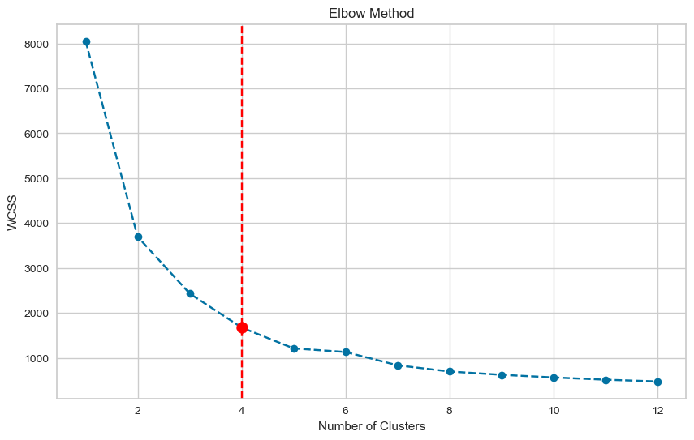

```
Optimal number of clusters (Elbow Method): 4
```

```python
# Determine Optimal Clusters (Elbow & Silhouette Method)
wcss = []
rt = sr+1
for i in range(1, rt):
    kmeans = KMeans(n_clusters=i, init='k-means++', random_state=42)
    kmeans.fit(reduced_df)
    wcss.append(kmeans.inertia_)

# Plot the Elbow Method graph
plt.figure(figsize=(10, 6))
plt.plot(range(1, rt), wcss, marker='o', linestyle='--')
plt.title('Elbow Method')
plt.xlabel('Number of Clusters')
plt.ylabel('WCSS')

# # Use KneeLocator to find the elbow point
knee = KneeLocator(range(1, rt), wcss, curve='convex', direction='decreasing',S=1)
optimal_clusters_elbow = knee.elbow

# Highlight the elbow point on the plot
plt.axvline(x=optimal_clusters_elbow, color='red', linestyle='--', label=f'Optimal k = {optimal_clusters_elbow}')
plt.scatter(optimal_clusters_elbow, wcss[optimal_clusters_elbow - 1], color='red', s=100, zorder=5)  # Highlight the point

plt.show()

print(f"Optimal number of clusters (Elbow Method): {optimal_clusters_elbow}")
```

### 5.3. Silhouette Score

**Silhouette Score** is a metric used to evaluate the quality of clustering by measuring how well each data point fits within its assigned cluster. The Silhouette Score (S) is calculated as: $$ S = \frac{b - a}{\max(a, b)} $$

where:

- $𝑎$ is the **average intra-cluster distance** (how close a point is to other points in the same cluster).
- $𝑏$ is the **average nearest-cluster distance** (how far a point is from points in the closest neighboring cluster).

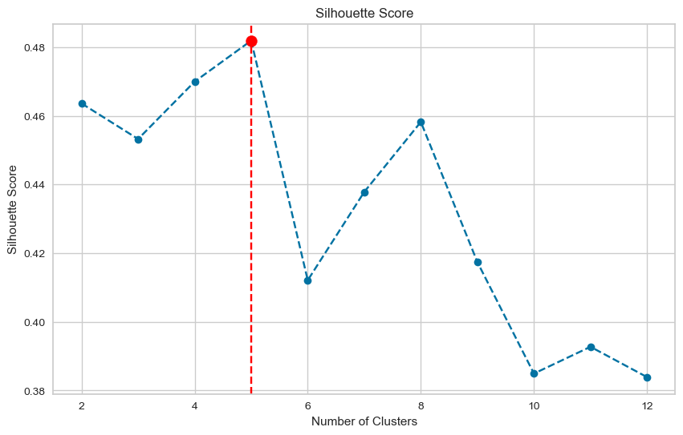

```python
# Silhouette Score
silhouette_scores = []
for i in range(2, rt):
    kmeans = KMeans(n_clusters=i, init='k-means++', random_state=42)
    kmeans.fit(reduced_df)
    score = silhouette_score(reduced_df, kmeans.labels_)
    silhouette_scores.append(score)

# Silhouette Polts
optimal_clusters_silhouette = np.argmax(silhouette_scores) + 2
max_silhouette_score = max(silhouette_scores)

plt.figure(figsize=(10, 6))
plt.plot(range(2, rt), silhouette_scores, marker='o', linestyle='--')
plt.axvline(x=optimal_clusters_silhouette, color='red', linestyle='--', label=f'Best k = {optimal_clusters_silhouette}')
plt.scatter(optimal_clusters_silhouette, max_silhouette_score, color='red', s=100, zorder=5)
plt.title('Silhouette Score')
plt.xlabel('Number of Clusters')
plt.ylabel('Silhouette Score')
plt.show()
```

### 5.4. Silhouette Plots

The **Silhouette Plot** is used to evaluate the quality of clustering by visualizing how well each data point fits within its assigned cluster. It provides insights into:

- **Cluster separation**: Measures how distinct clusters are from one another.
- **Intra-cluster cohesion**: Shows how tightly grouped points are within the same cluster.
- **Misclassified points**: Identifies points that may belong to a different cluster.

Each cluster’s silhouette width represents how similar its points are compared to neighboring clusters. A **higher silhouette score** indicates **better-defined clusters**, while a **low or negative score** suggests **overlapping or poorly separated clusters**.

Silhouette plots help assess whether the chosen number of clusters (K) is appropriate, guiding refinements in the clustering process.

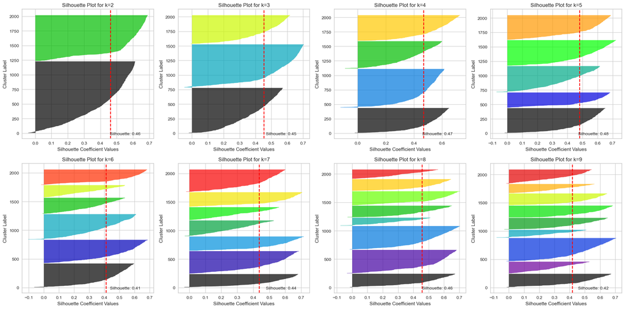

```
Maximum Silhouette Score: 0.48
Optimal number of clusters (Silhouette Score): 5
```

```python
# Silhouette Plot
def plot_silhouette(n_clusters, X):
    fig, axes = plt.subplots(2, 4, figsize=(20, 10))
    axes = axes.flatten()

    for i, k in enumerate(range(2, 10)):
        kmeans = KMeans(n_clusters=k, random_state=42)
        cluster_labels = kmeans.fit_predict(X)
        silhouette_avg = silhouette_score(X, cluster_labels)
        sample_silhouette_values = silhouette_samples(X, cluster_labels)

        y_lower = 10
        for j in range(k):
            ith_cluster_silhouette_values = sample_silhouette_values[np.where(cluster_labels == j)]
            ith_cluster_silhouette_values.sort()
            size_cluster_j = ith_cluster_silhouette_values.shape[0]
            y_upper = y_lower + size_cluster_j
            color = cm.nipy_spectral(float(j) / k)
            axes[i].fill_betweenx(np.arange(y_lower, y_upper), 0, ith_cluster_silhouette_values, facecolor=color, edgecolor=color, alpha=0.7)
            y_lower = y_upper + 10

        axes[i].set_title(f'Silhouette Plot for k={k}')
        axes[i].set_xlabel('Silhouette Coefficient Values')
        axes[i].set_ylabel('Cluster Label')
        axes[i].axvline(x=silhouette_avg, color='red', linestyle='--')
        axes[i].text(0.9, 0.02, f'Silhouette: {silhouette_avg:.2f}', transform=axes[i].transAxes, fontsize=10, verticalalignment='bottom', horizontalalignment='right')

    plt.tight_layout()
    plt.show()

plot_silhouette(optimal_clusters_silhouette, reduced_df)
print(f"Maximum Silhouette Score: {max_silhouette_score:.2f}")
print(f"Optimal number of clusters (Silhouette Score): {optimal_clusters_silhouette}")
```

Beyond k=5, the cluster quality begins to deteriorate. The segments become less distinct, showing more variation in cluster sizes and increased overlap between segments. This is accompanied by lower average silhouette widths, indicating diminishing returns from additional clusters. The decline in cluster quality is particularly evident in the plots for k=6 through k=9, where the silhouette widths become progressively less uniform and cluster sizes more imbalanced.

```python
# # Initialize lists to store the metrics
# chi_scores = []
# dbi_scores = []
# k_range = range(2, rt)
# # Compute CHI and DBI for different values of K
# for i in k_range:
#     kmeans = KMeans(n_clusters=i, init='k-means++', random_state=42, n_init=10)
#     labels = kmeans.fit_predict(reduced_df)

#     # Calculate CHI and DBI scores
#     chi_scores.append(calinski_harabasz_score(reduced_df, labels))
#     dbi_scores.append(davies_bouldin_score(reduced_df, labels))

# # Identify optimal K values based on CHI (max) and DBI (min)
# optimal_clusters_chi = k_range[np.argmax(chi_scores)]
# optimal_clusters_dbi = k_range[np.argmin(dbi_scores)]

# # Plot CHI Score
# plt.figure(figsize=(10, 6))
# plt.plot(k_range, chi_scores, marker='o', linestyle='--', label="CHI Score")
# plt.axvline(x=optimal_clusters_chi, color='red', linestyle='--', label=f'Best k = {optimal_clusters_chi}')
# plt.scatter(optimal_clusters_chi, max(chi_scores), color='red', s=100, zorder=5)
# plt.title('Calinski-Harabasz Index')
# plt.xlabel('Number of Clusters')
# plt.ylabel('CHI Score (Higher is Better)')
# plt.legend()
# plt.show()

# # Plot DBI Score
# plt.figure(figsize=(10, 6))
# plt.plot(k_range, dbi_scores, marker='o', linestyle='--', label="DBI Score")
# plt.axvline(x=optimal_clusters_dbi, color='red', linestyle='--', label=f'Best k = {optimal_clusters_dbi}')
# plt.scatter(optimal_clusters_dbi, min(dbi_scores), color='red', s=100, zorder=5)
# plt.title('Davies-Bouldin Index')
# plt.xlabel('Number of Clusters')
# plt.ylabel('DBI Score (Lower is Better)')
# plt.legend()
# plt.show()

# # Output optimal K values
# optimal_clusters_chi, optimal_clusters_dbi
```

### 5.5. Optimal K

The optimal number of clusters was determined by analyzing both the elbow method and silhouette analysis. The elbow method, implemented through KneeLocator, identified k=4 as the optimal point where adding more clusters yields diminishing returns in Within-Cluster Sum of Squares (WCSS). Conversely, the silhouette analysis indicated k=5 as the optimal choice, demonstrating the highest silhouette score of 0.48 and displaying well-balanced cluster characteristics.

Following the conservative principle of cluster selection,**the minimum value between these two metrics (k=4) was chosen as the final optimal number of clusters**. This choice ensures the model maintains strong cluster cohesion while avoiding over-segmentation, providing a practical balance between statistical validity and interpretability. This conservative approach aligns with business requirements for meaningful and actionable customer segments.

```python
optimal_k = min(optimal_clusters_elbow, optimal_clusters_silhouette)
print(f"Final Optimal Number of Clusters: {optimal_k}")
```

```
Final Optimal Number of Clusters: 4
```

## 6. Cluster Analysis

### 6.1. 3D Visualization of Customer Segmentation Using PCA

```python
# Apply KMeans Clustering with Optimal K
kmeans = KMeans(n_clusters=optimal_k, random_state=42, n_init=10)
df['Cluster'] = kmeans.fit_predict(X_transformed)+1

# PCA for Visualization
# Perform PCA with 3 components
pca = PCA(n_components=3)
X_pca = pca.fit_transform(X_transformed)
df['PCA1'] = X_pca[:, 0]
df['PCA2'] = X_pca[:, 1]
df['PCA3'] = X_pca[:, 2]

# Create a 3D scatter plot with Plotly
fig = go.Figure()

# Define colors for clusters
colors = px.colors.qualitative.Plotly  # Use Plotly's default qualitative colors

# Add data points for each cluster separately
for cluster in sorted(df['Cluster'].unique()):
    cluster_data = df[df['Cluster'] == cluster]
    fig.add_trace(go.Scatter3d(
        x=cluster_data['PCA1'],  # PCA Component 1
        y=cluster_data['PCA2'],  # PCA Component 2
        z=cluster_data['PCA3'],  # PCA Component 3
        mode='markers',
        marker=dict(
            size=5,  # Marker size
            opacity=0.7  # Transparency
        ),
        name=f'Cluster {cluster}',  # Legend label
        hovertext=cluster_data.index,  # Tooltip: Show customer ID or index
        hovertemplate='Customer ID: %{hovertext}<br>PCA1: %{x}<br>PCA2: %{y}<br>PCA3: %{z}'  # Custom tooltip
    ))

# Set the title and layout details
fig.update_layout(
    title=dict(text='3D Visualization of Customer Clusters in PCA Space', x=0.5),  # Centered title
    scene=dict(
        xaxis=dict(title='PCA Component 1', backgroundcolor="#fcf0dc", gridcolor='white'),
        yaxis=dict(title='PCA Component 2', backgroundcolor="#fcf0dc", gridcolor='white'),
        zaxis=dict(title='PCA Component 3', backgroundcolor="#fcf0dc", gridcolor='white'),
    ),
    width=900,  # Plot width
    height=800  # Plot height
)

# Show the plot
fig.show()

# pca = PCA(n_components=2)
# X_pca = pca.fit_transform(X_transformed)
# df['PCA1'] = X_pca[:, 0]
# df['PCA2'] = X_pca[:, 1]

# # PCA Visualization
# plt.figure(figsize=(10, 6))
# sns.scatterplot(x=df['PCA1'], y=df['PCA2'], hue=df['Cluster'], palette='tab10', alpha=0.7)
# plt.xlabel('PCA Component 1')
# plt.ylabel('PCA Component 2')
# plt.title('Customer Segmentation - PCA Visualization')
# plt.legend(title='Cluster')
# plt.show()

# # Cluster Distribution with Data Labels
# plt.figure(figsize=(8, 8))
# ax = sns.countplot(x=df['Cluster'], palette='tab10', hue=df['Cluster'], legend=False)  # Add hue to avoid warning
# plt.xlabel('Cluster')
# plt.ylabel('Number of Customers')
# plt.title('Cluster Distribution')

# # Add data labels
# for p in ax.patches:
#     ax.annotate(
#         f'{int(p.get_height())}',  # Text to display (count of customers)
#         (p.get_x() + p.get_width() / 2., p.get_height()),  # Position of the label
#         ha='center',  # Horizontal alignment
#         va='center',  # Vertical alignment
#         xytext=(0, 10),  # Offset from the bar
#         textcoords='offset points'
#     )

# plt.show()
```

[output not shown]

### 6.2. Cluster Distributiom

The cluster analysis reveals a relatively balanced distribution across four segments, with cluster sizes ranging from 426 to 661 customers. **Cluster 2 represents the largest segment with 661 customers (33%)**, while the remaining clusters demonstrate similar sizes: **Cluster 4 with 465 customers (23%)**, **Cluster 3 with 448 customers (22%)**, and **Cluster 1 with 426 customers (21%)**. This balanced distribution suggests a natural segmentation of the customer base, with no single segment being overly dominant or insignificantly small, indicating meaningful customer groupings for business analysis.

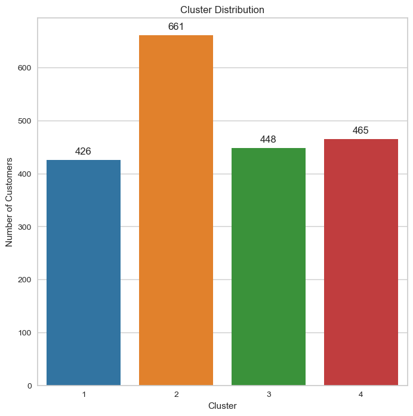

```python
# Cluster Distribution with Data Labels (2D)
plt.figure(figsize=(8, 8))
ax = sns.countplot(x=df['Cluster'], palette='tab10', hue=df['Cluster'], legend=False)  # Add hue to avoid warning
plt.xlabel('Cluster')
plt.ylabel('Number of Customers')
plt.title('Cluster Distribution')

# Add data labels
for p in ax.patches:
    ax.annotate(
        f'{int(p.get_height())}',  # Text to display (count of customers)
        (p.get_x() + p.get_width() / 2., p.get_height()),  # Position of the label
        ha='center',  # Horizontal alignment
        va='center',  # Vertical alignment
        xytext=(0, 10),  # Offset from the bar
        textcoords='offset points'
    )

plt.show()
```

### 6.3. Customer Behaviour Analysis

A comprehensive breakdown of customer behavior reveals key insights into demographics, purchasing patterns, subscription preferences, and shopping channels. Visual representations, including tables, radar charts (for numerical features), and bar graphs (for categorical features), illustrate how different customer segments interact with products and services. These insights provide a data-driven foundation for crafting targeted marketing strategies and enhancing customer engagement.

```python
# Analyze Customer Behavior
cluster_analysis_numeric = df.groupby('Cluster')[numeric_features].mean()
cluster_analysis_categorical = df.groupby('Cluster')[categorical_features].agg(lambda x: x.value_counts().index[0])

# Combine numerical and categorical analysis
cluster_analysis = pd.concat([cluster_analysis_numeric, cluster_analysis_categorical], axis=1)
cluster_analysis
```

| Cluster | Age | Annual_Income | Spending_Score | Purchase_Frequency | Customer_Tenure | Gender | Subscription_Type | Channel | Product_Category |
| --- | --- | --- | --- | --- | --- | --- | --- | --- | --- |
| 1 | 22.262911 | 102849.694836 | 84.643192 | 16.938967 | 2.403756 | Female | Standard | Online | Clothing |
| 2 | 58.000000 | 86663.517398 | 29.391831 | 7.411498 | 7.030257 | Female | Standard | In-Store | Home & Kitchen |
| 3 | 37.553571 | 103236.535714 | 59.729911 | 10.598214 | 4.435268 | Male | Standard | Online | Clothing |
| 4 | 30.395699 | 50507.774194 | 71.782796 | 8.694624 | 3.567742 | Male | Basic | Online | Electronics |

#### 6.3.1. Cluster 1: Young Digital-Savvy Spenders

The perfect gender balance (218:208) suggests this segment transcends traditional gender-based marketing approaches. Their overwhelming preference for digital channels (294 online, 89 mobile app) demonstrates a strong digital-first mindset, with minimal in-store engagement (43). The high proportion of Premium and Standard subscriptions (172:218) with minimal Basic subscriptions (36) indicates not just willingness but eagerness to pay for enhanced services and experiences.

The product distribution reveals a sophisticated, lifestyle-driven pattern. The dominance of Clothing (120), Electronics (79), and Beauty (71) suggests these customers view shopping as a form of self-expression and lifestyle enhancement. Their significant engagement with Toys (43) and Sports (38) categories further indicates an active, experiential lifestyle. This cluster represents the future of retail - digitally native consumers who seamlessly blend high-value purchases across multiple categories with premium service expectations.

#### 6.3.2. Cluster 2: Established Traditional Shoppers

Despite equal gender distribution (331:330), this largest segment shows distinctive traditional shopping behaviors. Their overwhelming preference for in-store shopping (472) versus online (132) and mobile (57) reflects a strong value for physical retail experiences. The balanced distribution across subscription tiers (258 Standard, 215 Basic, 188 Premium) suggests thoughtful evaluation of service benefits rather than automatic premium adoption.

#### 6.3.3. Cluster 3: Mid-Career Digital Enthusiasts

The slight male skew (238:210) and remarkably balanced channel usage across online (183), in-store (165), and mobile (100) platforms indicates a truly omnichannel consumer group. Their preference for higher-tier subscriptions (209 Standard, 157 Premium) with minimal Basic subscriptions (82) suggests recognition of service value propositions.

Their product preferences reveal sophisticated, lifestyle-driven consumption patterns. The even distribution across Clothing (95), Electronics (92), and Home & Kitchen (87) indicates balanced lifestyle priorities. The significant engagement with Beauty (59) and Sports (45) categories suggests active lifestyle maintenance. This segment exemplifies the modern omnichannel consumer, effortlessly navigating between digital and physical retail environments while maintaining high engagement across diverse categories.

#### 6.3.4. Cluster 4: Value-Seeking Tech Adopters

Their product preferences reveal calculated decision-making. The focus on Electronics (104) suggests tech-savvy consumers, while significant engagement with Clothing (89) and Beauty (77) indicates they don't compromise on personal style. The substantial interest in Home & Kitchen (67) and Sports (54) categories suggests holistic lifestyle maintenance within budget constraints. This cluster represents the emerging value-conscious digital consumer, leveraging technology and channel selection to maximize shopping value while maintaining lifestyle quality despite income constraints.

```python
# Normalize the numeric features for the radar chart
scaler = MinMaxScaler()
cluster_analysis_normalized = pd.DataFrame(
    scaler.fit_transform(cluster_analysis_numeric),
    columns=cluster_analysis_numeric.columns,
    index=cluster_analysis_numeric.index
)

# Create a 2x2 grid of subplots
fig = make_subplots(
    rows=2, cols=2,  # 2 rows x 2 columns
    specs=[[{'type': 'polar'}] * 2] * 2,  # Each subplot is a radar chart
    subplot_titles=[f'Cluster {i}' for i in cluster_analysis_normalized.index]  # Titles for each subplot
)

# Add a radar chart for each cluster
for i, cluster in enumerate(cluster_analysis_normalized.index):
    row = (i // 2) + 1  # Calculate row position (1 to 5)
    col = (i % 2) + 1   # Calculate column position (1 or 2)

    fig.add_trace(
        go.Scatterpolar(
            r=cluster_analysis_normalized.loc[cluster].values,  # Values for each feature
            theta=numeric_features,  # Feature names
            fill='toself',  # Fill the area under the line
            name=f'Cluster {cluster}',  # Legend label
            line_color=px.colors.qualitative.Plotly[i],
            fillcolor=px.colors.qualitative.Plotly[i],
            hovertemplate='%{theta}: %{r:.2f}'  # Tooltip with feature name and value
        ),
        row=row, col=col  # Position in the grid
    )

# Update layout for the radar charts
fig.update_layout(
    title='Radar Charts of Customer Behavior by Cluster',
    showlegend=False,  # Hide legend (optional)
    polar=dict(
        radialaxis=dict(
            visible=True,
            range=[0, 1]  # Normalized range
        )
    ),
    width=1000,  # Adjust width
    height=1000  # Adjust height
)

# Show the grid of radar charts
fig.show()
```

[output not shown]

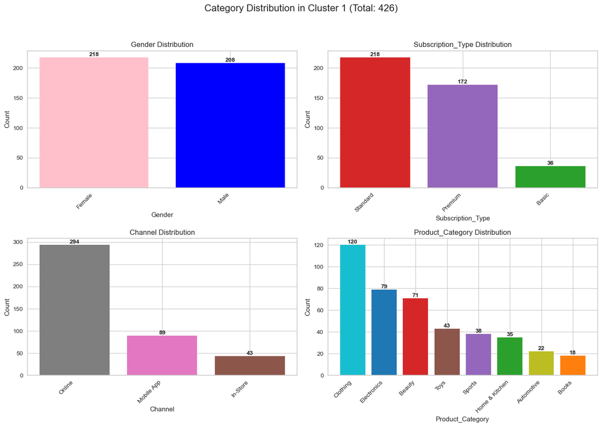

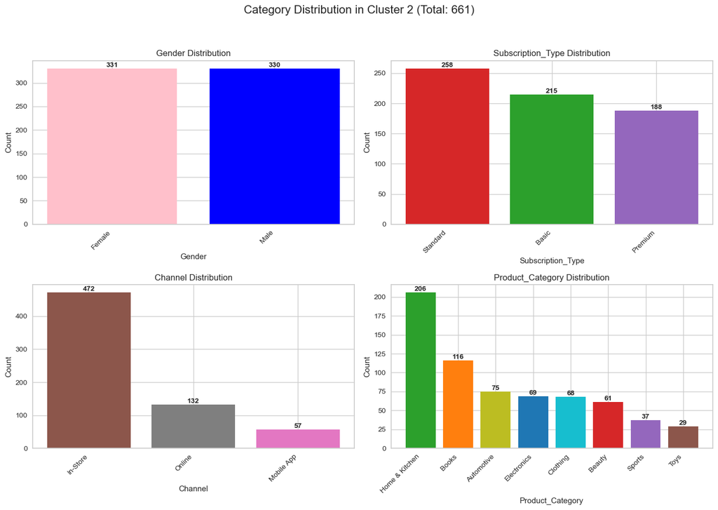

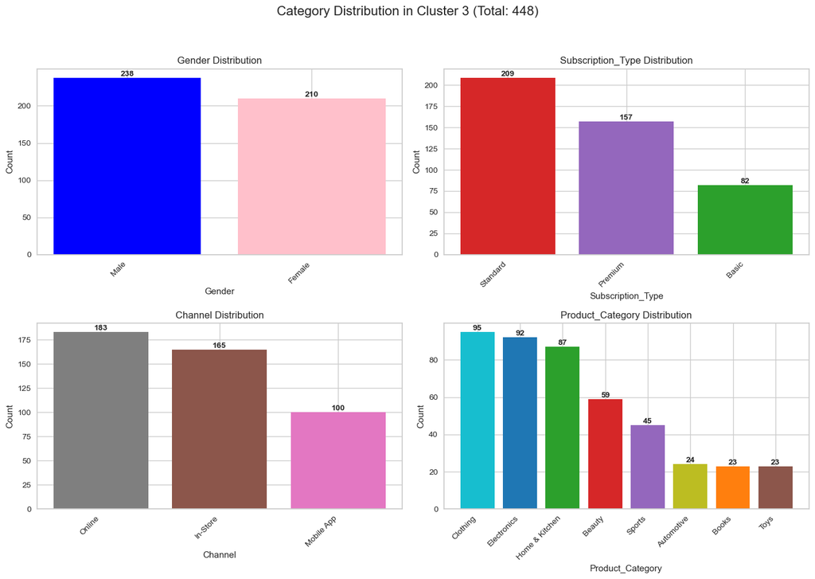

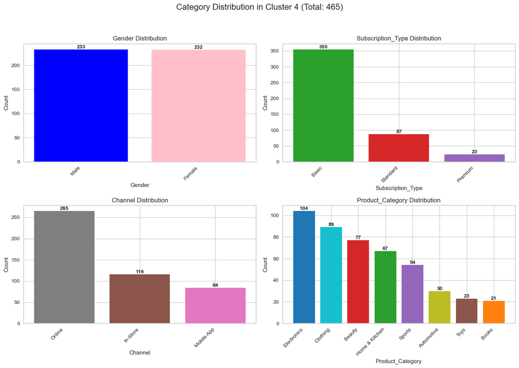

```python
# Category Distribution per Cluster Visualization
clusters_sorted = sorted(df['Cluster'].unique())
for cluster in clusters_sorted:
    total_count = df[df['Cluster'] == cluster].shape[0]
    fig, axes = plt.subplots(2, 2, figsize=(14, 10))
    fig.suptitle(f'Category Distribution in Cluster {cluster} (Total: {total_count})', fontsize=16)

    for ax, category in zip(axes.flatten(), categorical_features):
        category_counts = df[df['Cluster'] == cluster][category].value_counts()
        colors = sns.color_palette('tab10', len(category_counts))
        unique_categories = df[categorical_features].melt()['value'].unique()
        color_map = {val: 'blue' if val == 'Male' else 'pink' if val == 'Female' else color for val, color in zip(unique_categories, sns.color_palette('tab10', len(unique_categories)))}
        colors = [color_map[val] for val in category_counts.index]

        bars = ax.bar(category_counts.index, category_counts.values, color=colors)
        ax.set_xlabel(category)
        ax.set_ylabel('Count')
        ax.set_title(f'{category} Distribution')
        ax.set_xticks(range(len(category_counts.index)))
        ax.set_xticklabels(category_counts.index, rotation=45, ha='right')

        # Add data labels
        for bar in bars:
            ax.text(bar.get_x() + bar.get_width()/2, bar.get_height(), f'{int(bar.get_height())}',
                    ha='center', va='bottom', fontsize=10, fontweight='bold')

    plt.tight_layout(rect=[0, 0, 1, 0.95])
    plt.show()

# for category in categorical_features:
#     category_counts = df.groupby(['Cluster', category])['Product_Category'].count().unstack()
#     ax = category_counts.plot(kind='bar', figsize=(12, 6), stacked=True)
#     plt.xlabel('Cluster')
#     plt.ylabel(f'Count of {category}')
#     plt.title(f'{category} Distribution Across Clusters')
#     plt.legend(title=category)

#     # Add data labels
#     for container in ax.containers:
#         ax.bar_label(container, fmt='%d', label_type='edge', fontsize=10, padding=3)

#     plt.show()
```

## 7. Marketing Strategies & Recommendation

The analysis reveals distinct opportunities for targeted marketing interventions across each customer segment. For **Cluster 1**, the focus should be on leveraging digital channels and premium experiences to enhance engagement with these high-value customers. Their strong adoption of premium services suggests potential for exclusive offerings and personalized experiences.

**Cluster 3**'s sophisticated omnichannel behavior presents opportunities for integrated marketing approaches. Their balanced use of channels and premium subscription preference suggests potential for advanced personalization and seamless cross-channel experiences. Marketing efforts should focus on lifestyle enhancement and premium service offerings.

For **Cluster 4**, value proposition and digital engagement are crucial. Despite lower incomes, their strategic shopping behavior and tech focus indicate opportunities for smart shopping tools and value-based rewards. Digital-first approaches with practical benefits will resonate most effectively with this segment.

| Cluster | Cluster Segment | Description | Marketing Strategies | Recommendations |
| --- | --- | --- | --- | --- |
| **1** | Young Digital-Savvy Spenders | Young, digitally-native consumers with balanced gender distribution, premium subscription preferences, focusing on fashion and electronics | - Exclusive digital promotions - AI-powered personalization - Premium loyalty programs - Influencer partnerships | - VIP early access programs - Cross-category bundle rewards - Premium lifestyle perks - Mobile-first shopping experience |
| **2** | Established Traditional Shoppers | Traditional shoppers with strong in-store preferences, balanced subscription tiers, focusing on home and lifestyle products | - In-store experiential events - Multi-tier loyalty programs - Home-focused workshops - Targeted email campaigns | - Enhanced store services - Bulk purchase incentives - Home product bundles - Value-added services |
| **3** | Mid-Career Digital Enthusiasts | Omnichannel shoppers with higher-tier subscriptions, showing balanced interest across categories | - Integrated channel campaigns - Advanced personalization - Premium category promotions - Lifestyle content marketing | - Channel integration benefits - Premium service upgrades - Cross-category rewards - Personalized assistance |
| **4** | Value-Seeking Tech Adopters | Price-conscious digital shoppers with basic subscriptions, focusing on electronics and practical purchases | - Value-driven digital campaigns - Tech-focused promotions - Smart shopping tools - Budget loyalty program | - Tech value bundles - Flexible payment options - Price alert systems - Digital rewards program |

## 8. Discussion

The analysis reveals fundamental insights about customer behavior patterns, showing that shopping preferences are predominantly influenced by lifestyle and age rather than traditional demographic factors like gender or income. Digital engagement and channel preferences demonstrate significant variation across segments, driven by lifestyle choices rather than age alone. This is particularly evident in cross-category purchasing patterns, which offer opportunities for strategic bundling and integrated promotions. Notably, price sensitivity exists across all income levels but manifests uniquely in each segment's purchasing behavior.

Channel and service preferences emerge as critical differentiators among customer segments. A clear distinction exists between digital-first consumers and traditional retail shoppers, with multi-channel engagement patterns strongly correlating with customer lifestyle segments. These channel preferences significantly impact marketing strategy effectiveness, while digital adoption shows stronger correlation with lifestyle choices than age demographics. This understanding is crucial for developing targeted marketing approaches.

Value and service perception varies significantly across segments, with subscription tier selection serving as a strong indicator of service value perception and customer engagement level. Interestingly, the appeal of premium services doesn't directly correlate with income levels, suggesting more complex drivers of service adoption. While the importance of value proposition remains consistent across all segments, it requires different approaches to resonate effectively. Product category preferences demonstrate strong alignment with specific channel choices and service expectations.

From a marketing perspective, these findings emphasize the need for highly tailored channel strategies based on distinct segment engagement patterns. Product category focus should guide targeted promotional strategies, while cross-category bundling opportunities can be leveraged based on segment preferences. Marketing effectiveness ultimately depends on understanding and addressing segment-specific value perceptions, rather than relying on traditional demographic segmentation approaches. This nuanced understanding enables more sophisticated and effective marketing strategies that align with modern consumer behavior patterns.

## 9. Conclusion

The customer segmentation analysis reveals four distinct clusters, each with unique characteristics, preferences, and behaviors that demand tailored marketing approaches. Through comprehensive analysis of demographic, behavioral, and transactional data, clear patterns emerge that challenge traditional marketing assumptions.

Most notably, the analysis challenges conventional demographic-based marketing approaches, revealing that shopping behaviors are more strongly influenced by lifestyle choices and value perceptions than traditional demographic factors. The clear distinction between digital and traditional retail preferences, coupled with varying subscription tier adoption patterns, suggests the need for more sophisticated, channel-specific marketing strategies.

These insights provide a foundation for developing targeted marketing initiatives that align with modern consumer behavior patterns. Success in implementing these strategies will require careful consideration of channel preferences, value propositions, and service expectations specific to each segment, while maintaining consistency in overall brand positioning. By leveraging these insights, businesses can create more effective, personalized marketing approaches that resonate with each customer segment's unique characteristics and preferences.